# Correlation and Simple regression

17 nov 2016

## Inhoud

## Correlation

## Simulate data

```r
n          = 50
cijfers    = rnorm(n, 6, 1.6)
b.0        = 100
b.1        = .3
error      = rnorm(n, 0, 0.7)

IQ = b.0 + b.1 * cijfers + error
#IQ = group(IQ)

error       = rnorm(n, 0, 0.7)
betrouwbaar = 3.2 + .2 * IQ + error
```

## Explaining vairance

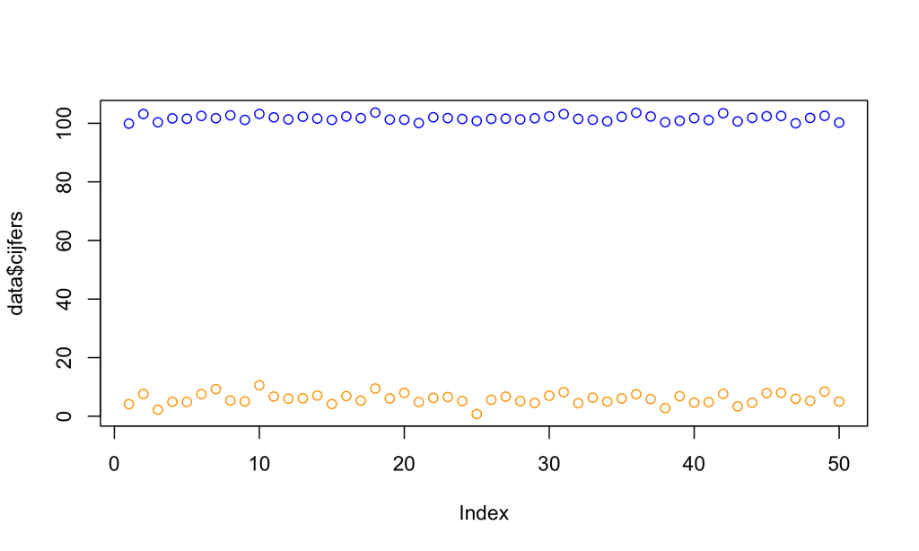

```r
cijfers        = data$cijfers
IQ             = data$IQ
mean.cijfers   = mean(cijfers)
mean.IQ        = mean(IQ)
N              = length(cijfers)

plot(data$cijfers, ylim=summary(c(data$cijfers, data$IQ))[c('Min.','Max.')], col='orange')
points(data$IQ, col='blue')
```

## Standarize

\[z = \frac{x_i - \bar{x}}{{sd}_x}\]

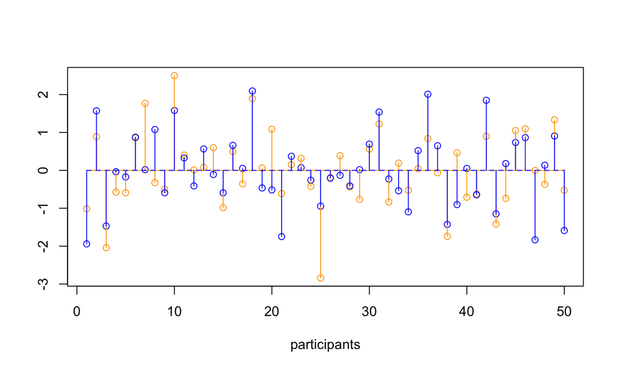

```r
data[, c('z.cijfers', 'z.IQ')] = scale(data[, c('cijfers', 'IQ')])

z.cijfers        = data$z.cijfers
z.IQ             = data$z.IQ

mean.z.cijfers   = mean(z.cijfers, na.rm=T)
mean.z.IQ        = mean(z.IQ,      na.rm=T)

plot(z.cijfers,
     ylim = summary(c(z.cijfers, z.IQ))[c('Min.','Max.')],
     col  = 'orange',
     ylab = "", xlab="participants")
points(z.IQ, col='blue')

# Add mean lines
lines(rep(mean.z.cijfers, N), col='orange')
lines(rep(mean.z.IQ,      N), col='blue', lt=2)

# Add vertical variance lines
segments(1:N, mean.z.cijfers, 1:N, z.cijfers, col='orange')
segments(1:N, mean.z.IQ, 1:N, z.IQ, col='blue')
```

## Covariance

\[{COV}_{xy} = \frac{\sum_{i=1}^N (x_i - \bar{x})(y_i - \bar{y})}{N-1}\]

```r
mean.cijfers = mean(cijfers, na.rm=T)
mean.IQ      = mean(IQ,      na.rm=T)

delta.cijfers = cijfers - mean.cijfers
delta.IQ      = IQ      - mean.IQ

prod = (cijfers - mean.cijfers) * (IQ - mean.IQ)

covariance = sum(prod) / (N - 1)
```

## Correlation

\[\frac{{COV}_{xy}}{S_xS_y}\]

```r
correlation = covariance / ( sd(cijfers) * sd(IQ) ); correlation
```

```
## [1] 0.684577
```

```r
cor(z.cijfers, z.IQ)
```

```
## [1] 0.684577
```

```r
cor(  cijfers,   IQ)
```

```
## [1] 0.684577
```

```r
sum( z.cijfers * z.IQ ) / (N - 1)
```

```
## [1] 0.684577
```

```r
x = c(1,-1,-1, 0,.5,-.5)
y = c(1,-1, 1, 1, 1, 1)
cbind(x,y,x*y)
```

```
##         x  y
## [1,]  1.0  1  1.0
## [2,] -1.0 -1  1.0
## [3,] -1.0  1 -1.0
## [4,]  0.0  1  0.0
## [5,]  0.5  1  0.5
## [6,] -0.5  1 -0.5
```

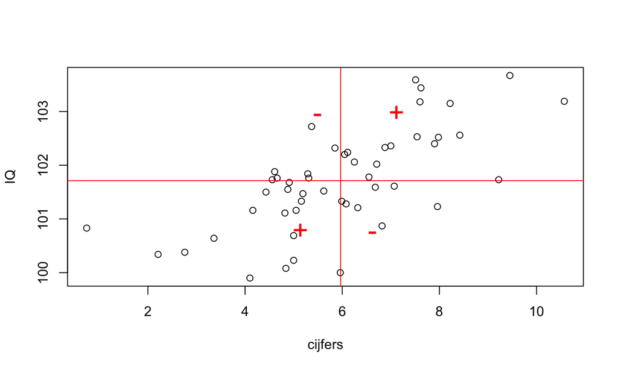

## Significance of a correlation

\[t_r = \frac{r \sqrt{N-2}}{\sqrt{1 - r^2}} \\ {df} = N - 2\]

```r
df = N-2
df
```

```
## [1] 48
```

```r
t.r = ( correlation*sqrt(df) ) / sqrt(1-correlation^2)
t.r
```

```
## [1] 6.50655
```

## Viualize

One-sample t-test

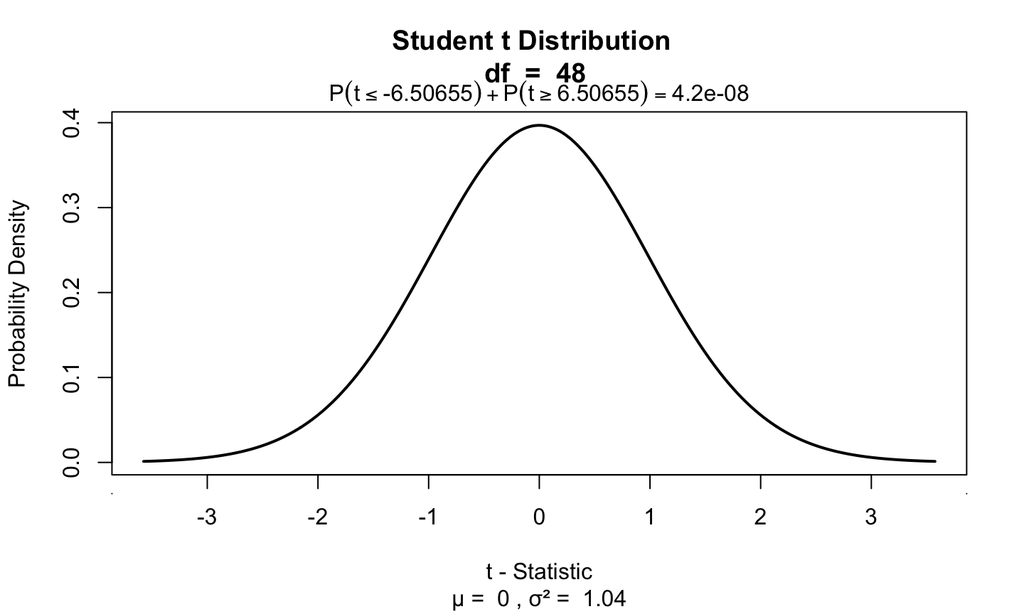

```r
if(!"visualize" %in% installed.packages()) { install.packages("visualize") }
library("visualize")

visualize.t(c(-t.r, t.r),df,section='tails')
```

## Partial correlation

## Venn diagram

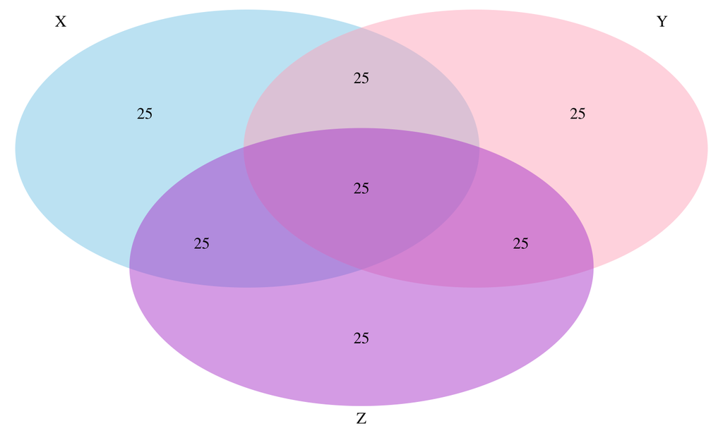

[output not shown]

```r
grid.newpage()
draw.triple.venn(area1 = 100, area2 = 100, area3 = 100,
                 n12 = 50,
                 n23 = 50,
                 n13 = 50,
                 n123 = 25,
                 category = c("X", "Y", "Z"), lty = "blank",
    fill = c("skyblue", "pink1", "mediumorchid"), cat.prompts = F)
```

## Partial correlation

\[r_{xy \cdot z} = \frac{r_{xy} - r_{xz} r_{yz}}{\sqrt{(1 - r_{xz}^2)(1 - r_{yz}^2)}}\]

```r
betrouwbaar = data$betrouwbaar

cor.cijfers.IQ            = cor(cijfers,IQ)
cor.cijfers.betrouwbaar   = cor(cijfers,betrouwbaar)
cor.IQ.betrouwbaar        = cor(IQ,betrouwbaar)

data.frame(cor.cijfers.IQ, cor.cijfers.betrouwbaar, cor.IQ.betrouwbaar)
```

```
##   cor.cijfers.IQ cor.cijfers.betrouwbaar cor.IQ.betrouwbaar
## 1       0.684577               0.3220983            0.33019
```

```r
teller = cor.cijfers.IQ - (cor.cijfers.betrouwbaar * cor.IQ.betrouwbaar)
noemer = sqrt( (1-cor.cijfers.betrouwbaar^2)*(1-cor.IQ.betrouwbaar^2) )

partial.correlation = teller / noemer

partial.correlation
```

```
## [1] 0.6470647
```

## Significance of parial correlation

One-sample t-test

```r
df = N - 3

t.pr = ( partial.correlation*sqrt(df) ) / sqrt(1-partial.correlation^2)
t.pr
```

```
## [1] 5.818269
```

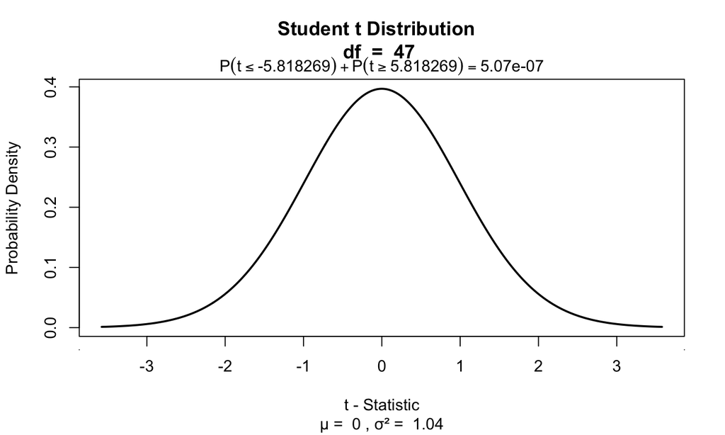

```r
visualize.t(c(-t.pr,t.pr),df,section='tails')
```

## Regression

One predictor

## Regression

\[y_i = b_0 + b_1 x_i + \epsilon_i\]

```r
set.seed(28736)

N     = 123
mu    = 120
sigma = 15
IQ    = rnorm(N, mu, sigma)

b_0   =  1
b_1   = .04
error = rnorm(N, 0, 1)

cijfers = b_0 + b_1 * IQ + error

data = data.frame(cijfers, IQ)
data = round(data, 2)

# Write data for use in SPSS
write.table(data, "IQ.csv", row.names=FALSE, col.names=TRUE, dec='.')
```

## The data

| cijfers | IQ |
| --- | --- |
| 5.75 | 151.13 |
| 7.61 | 120.42 |
| 7.26 | 131.77 |
| 3.43 | 98.32 |
| 6.95 | 124.57 |
| 6.16 | 115.57 |
| 5.37 | 117.38 |
| 5.96 | 122.13 |
| 3.04 | 110.83 |
| 6.03 | 114.28 |

[output cut: 113 more lines]

## Calculate regression parameters

\[{cijfer}_i = b_0 + b_1 {IQ}_i + \epsilon_i\]

```r
IQ      = data$IQ
cijfers = data$cijfers
```

## Calculate \(b_1\)

\[b_1 = r_{xy} \frac{s_y}{s_x}\]

```r
# Calculate b1

cor.cijfers.IQ = cor(cijfers,IQ)
sd.cijfers     = sd(cijfers)
sd.IQ          = sd(IQ)

b1 = cor.cijfers.IQ * ( sd.cijfers / sd.IQ )
b1
```

```
## [1] 0.04489104
```

## Calculate \(b_0\)

\[b_0 = \bar{y} - b_1 \bar{x}\]

```r
mean.cijfers = mean(cijfers)
mean.IQ      = mean(IQ)

b0 = mean.cijfers - b1 * mean.IQ
b0
```

```
## [1] 0.4167131
```

## The slope

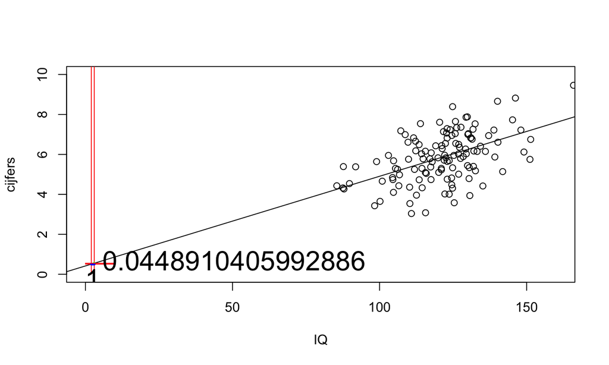

```r
# Extra

plot(IQ,cijfers, xlim=c(0, 160), ylim=c(0,10))
abline(lm(cijfers~IQ))
lines(c(2,2),c(0,200),col='red')
lines(c(3,3),c(0,200),col='red')
lines(c(3,3),c(b0 + b1 * 2,b0 + b1 * 3),col='green',lwd=3)
lines(c(0,10),rep(b0 + b1 * 2, 2),col='red')
lines(c(2,3), rep(b0 + b1 * 2, 2),col='blue',lwd=3)
lines(c(0,10),rep(b0 + b1 * 3, 2),col='red')

text(2.5, (b0 + b1 * 2),1, pos=1, cex=2)
text(3  , (b0 + b1 * 2.5),
     (b0 + b1 * 3)-(b0 + b1 * 2),
     pos=4,
     cex=2)
```

## Calculate t-values for b's

\[t_{n-p-1} = \frac{b - \mu_b}{{SE}_b}\]

Where \(n\) is the number of rows, \(p\) is the number of predictors, \(b\) is the beta coefficient and \({SE}_b\) its standard error.

```r
# Get Standard error's for b
fit <- lm(cijfers~IQ)
se = summary(fit)[4]$coefficients[,2]

se.b0 = se[1]; se.b0
```

```
## (Intercept)
##   0.8542378
```

```r
se.b1 = se[2]; se.b1
```

```
##          IQ
## 0.006998539
```

```r
# Calculate t's
mu.b0 = 0
mu.b1 = 0
t.b0  = (b0 - mu.b0) / se.b0; t.b0
```

```
## (Intercept)
##   0.4878187
```

```r
t.b1  = (b1 - mu.b1) / se.b1; t.b1
```

```
##       IQ
## 6.414345
```

```r
n     = nrow(data) # number of rows
p     = 1          # number of predictors
df.b0 = n - p - 1
df.b1 = n - p - 1
```

## P-values of \(b_0\)

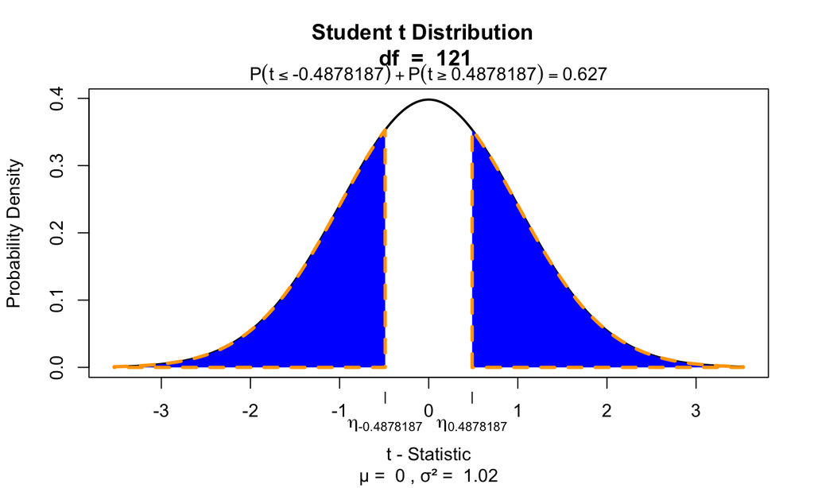

```r
if (!"visualize" %in% installed.packages()) {
  install.packages("visualize")}

library("visualize")

# p-value for b0
visualize.t(c(-t.b0,t.b0),df.b0,section='tails')
```

## P-values of \(b_1\)

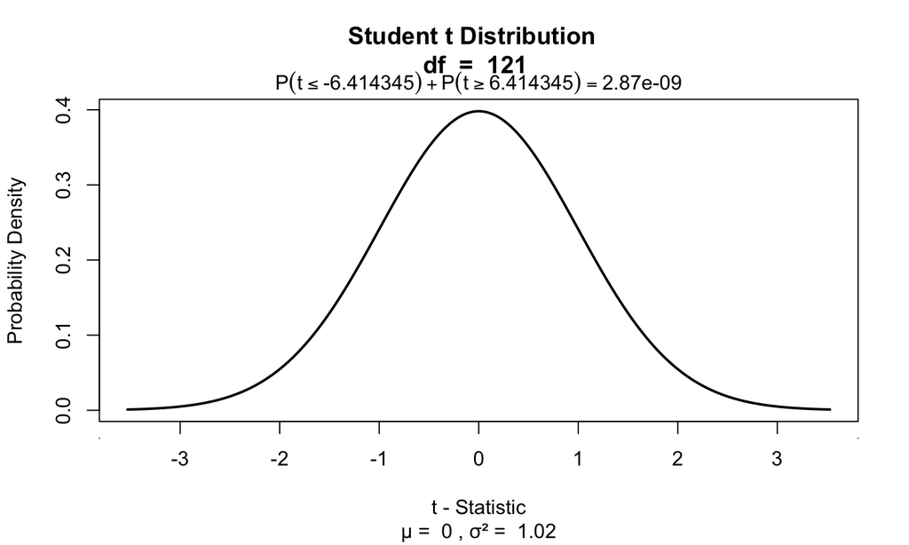

```r
# p-value for b1
visualize.t(c(-t.b1,t.b1),df.b1,section='tails')
```

## Define regression equation

\[\widehat{cijfer} = {model} = b_0 + b_1 {IQ}\]

So now we can add the expected cijfers based on this model

```r
data$expcijfers = b0 + b1 * IQ
```

## Expected values

Let's have a look

| cijfers | IQ | expcijfers |
| --- | --- | --- |
| 5.75 | 151.13 | 7.20109611499612 |
| 7.61 | 120.42 | 5.82249225819196 |
| 7.26 | 131.77 | 6.33200556899389 |
| 3.43 | 98.32 | 4.83040026094768 |
| 6.95 | 124.57 | 6.00879007667901 |
| 6.16 | 115.57 | 5.60477071128541 |
| 5.37 | 117.38 | 5.68602349477012 |
| 5.96 | 122.13 | 5.89925593761674 |
| 3.04 | 110.83 | 5.39198717884478 |
| 6.03 | 114.28 | 5.54686126891233 |

[output cut: 113 more lines]

## \(y\) vs \(\hat{y}\)

And lets have a look at this relation between expectation and reality

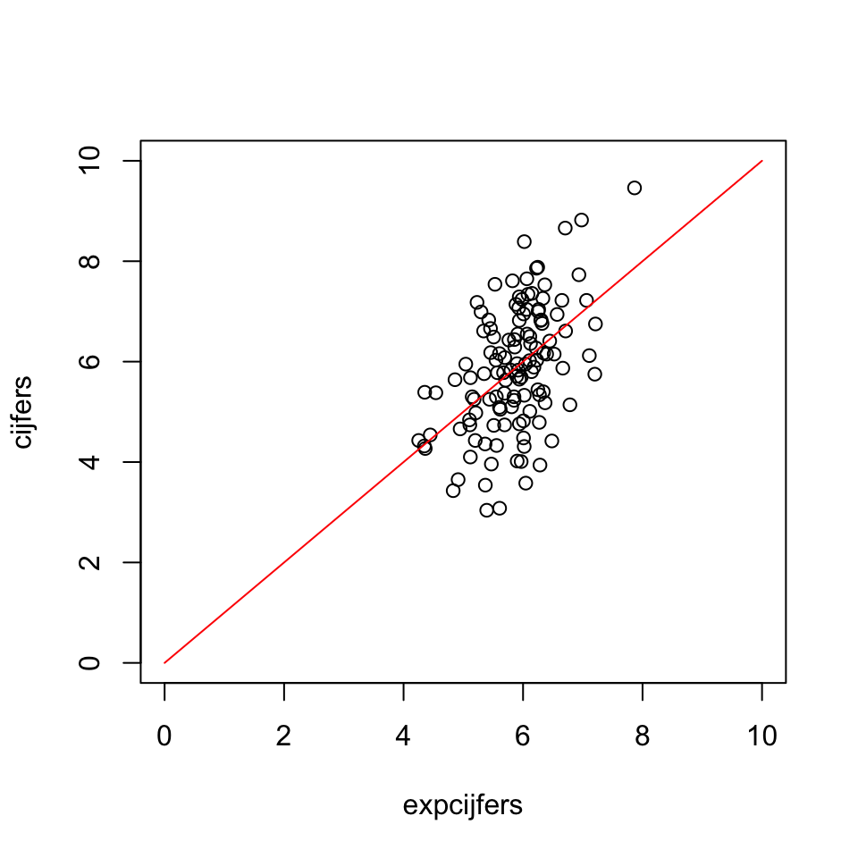

```r
expcijfers <- data$expcijfers

plot(expcijfers,cijfers, xlim = c(0,10), ylim = c(0,10))
lines(c(0,10), c(0,10), col='red')
```

## Error

The error / residual is the difference between expected and reality

```r
data$error = cijfers - expcijfers
```

| cijfers | IQ | expcijfers | error |
| --- | --- | --- | --- |
| 5.75 | 151.13 | 7.20109611499612 | -1.45109611499612 |
| 7.61 | 120.42 | 5.82249225819196 | 1.78750774180804 |
| 7.26 | 131.77 | 6.33200556899389 | 0.927994431006112 |
| 3.43 | 98.32 | 4.83040026094768 | -1.40040026094768 |
| 6.95 | 124.57 | 6.00879007667901 | 0.941209923320991 |
| 6.16 | 115.57 | 5.60477071128541 | 0.55522928871459 |
| 5.37 | 117.38 | 5.68602349477012 | -0.316023494770123 |
| 5.96 | 122.13 | 5.89925593761674 | 0.0607440623832556 |
| 3.04 | 110.83 | 5.39198717884478 | -2.35198717884478 |
| 6.03 | 114.28 | 5.54686126891233 | 0.483138731087672 |

[output cut: 113 more lines]

## Model fit

The fit of the model is the amount of error, which can be viewed in the correlation (\(r\)).

```r
r = cor(expcijfers,cijfers)
r
```

```
## [1] 0.503735
```

## Explained variance

```r
r^2
```

```
## [1] 0.2537489
```

## Explained variance visually

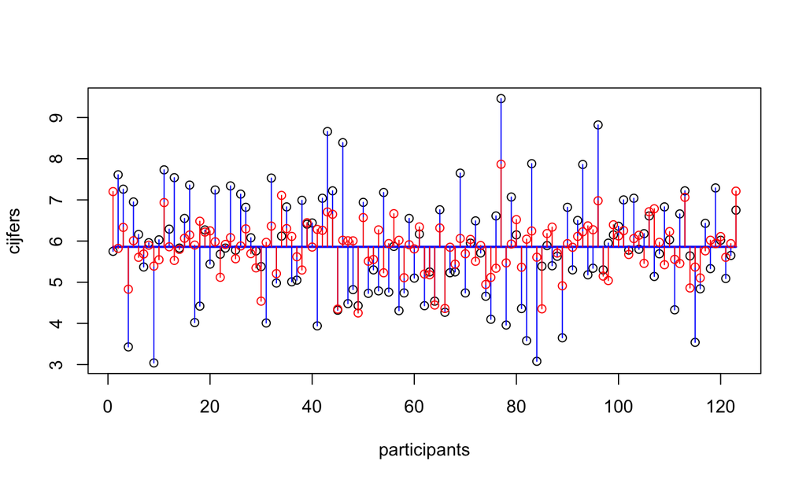

```r
# This is all the cijfers data
plot(cijfers,xlab='participants')
# With the mean
lines(1:n,rep(mean(cijfers),n),col='blue',lwd=2)

# The blue lines are the total variance, the deviation from the mean.
segments(1:n, cijfers, 1:n, mean(cijfers), col='blue')

# The model predicts the cijfers scores
points(1:n,expcijfers, col='red')

# The part of the variation that overlaps is the 'explained' variance.
segments(1:n, expcijfers, 1:n, mean(cijfers), col='red')
```

The part that does not overlap is therefore 'unexplained' variance. And because \(r^2\) is the explained variance, \(1 - r^2\) is the unexplained variance.

## Test model fit

Compare model to mean Y (cijfers) as model

\[F = \frac{(n-p-1) r^2}{p (1-r^2)}\]

```r
F = ( (n-p-1)*r^2 ) / ( p*(1-r^2) )
F
```

```
## [1] 41.14382
```

## Signal to noise

Given the description of explained variance, F can again be seen as a proportion of explained to unexplained variance. Also known as a signal to noise ratio.

```r
df.model = p # n = rows, p = predictors
df.error = n-p-1

SS_model = sum((expcijfers - mean(cijfers))^2)
SS_error = sum((cijfers - expcijfers)^2)
MS_model = SS_model / df.model
MS_error = SS_error / df.error
F = MS_model / MS_error
F
```

```
## [1] 41.14382
```

```r
SS_total = var(cijfers) * (n-1)
SS_total
```

```
## [1] 191.0732
```

```r
SS_model
```

```
## [1] 48.48462
```

```r
# Proportion explained variance
SS_model / SS_total
```

```
## [1] 0.2537489
```

```r
r^2
```

```
## [1] 0.2537489
```

## Visualize

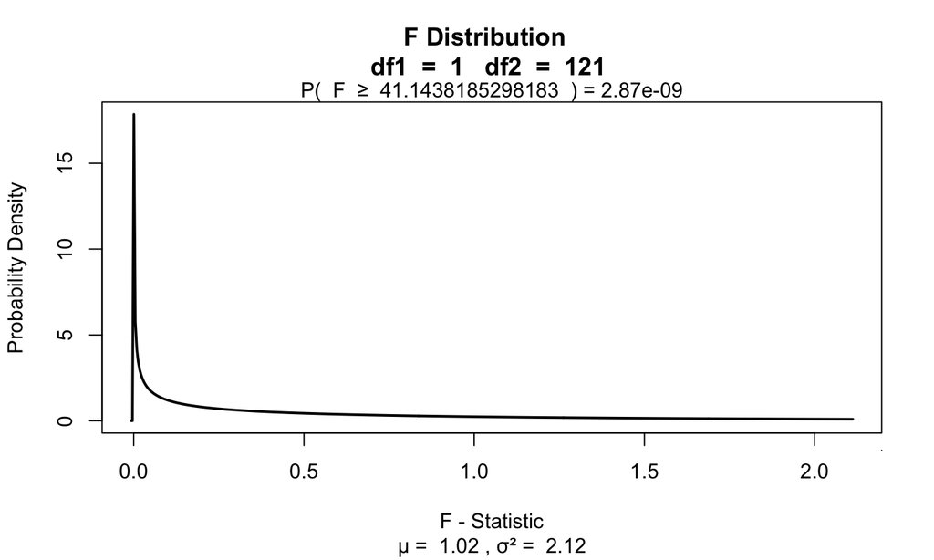

```r
visualize.f(F, df.model, df.error, section='upper')
```

## END

[@shklinkenberg](https://twitter.com/shklinkenberg)